# Are we doing better at reducing the total loss in large earthquakes?

Chen Chen

January 10, 2018

# Questions

1. Overall, are we doing better at reducing damages and fatality over the past 50 years?
2. Are the total deaths/damages correlated with the magnitude/depth/location of the earthquakes?
3. Is there a correlation between a country’s GDP/population and the total deaths/damages?

# Dataset

- [Significant earthquake database](https://www.ngdc.noaa.gov/nndc/struts/form?t=101650&s=1&d=1) from NOAA: damaging earthquakes from 2150 B.C. to present.
- Earthquakes between 1967 and 2017 were downloaded, containing information on the earthquake data, location, depth, magnitude, total deaths, total damages, etc.
- World Bank Database on Country’s [GDP](http://databank.worldbank.org/data/reports.aspx?source=2&series=NY.GDP.MKTP.CD&country=#) and [population](http://databank.worldbank.org/data/reports.aspx?source=2&series=SP.POP.TOTL&country=)

# Visualization of the Data

- No decrease in the total deaths/damages in large earthquakes

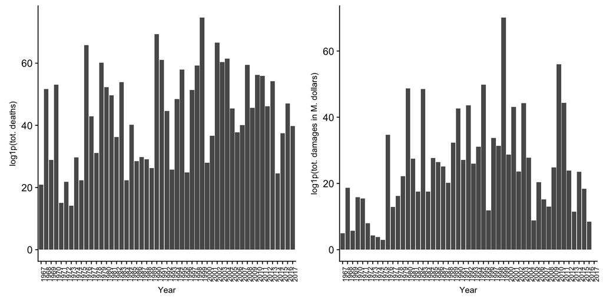

# Visualization of the Data

- Positive correlation of earthquake magnitude and the total deaths/damages in an earthquake.

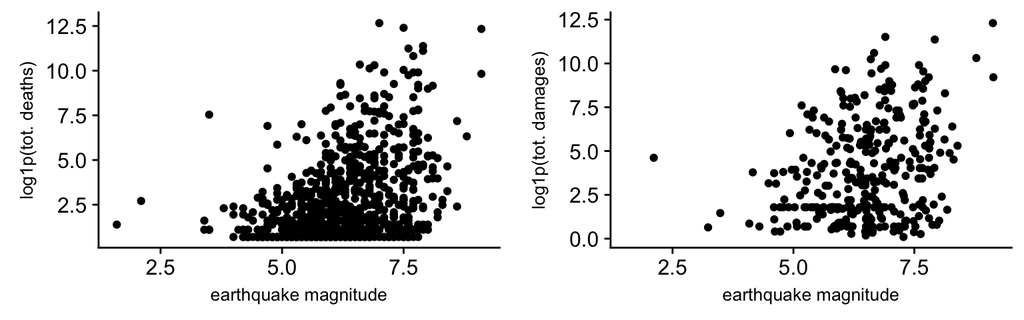

- More deaths/damages are correlated with shallower earthquakes.

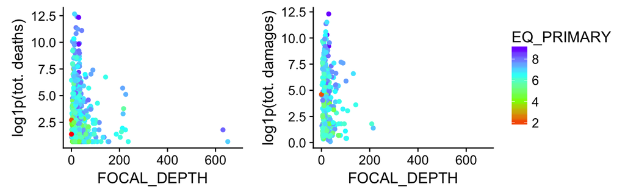

# Visualization of the Data

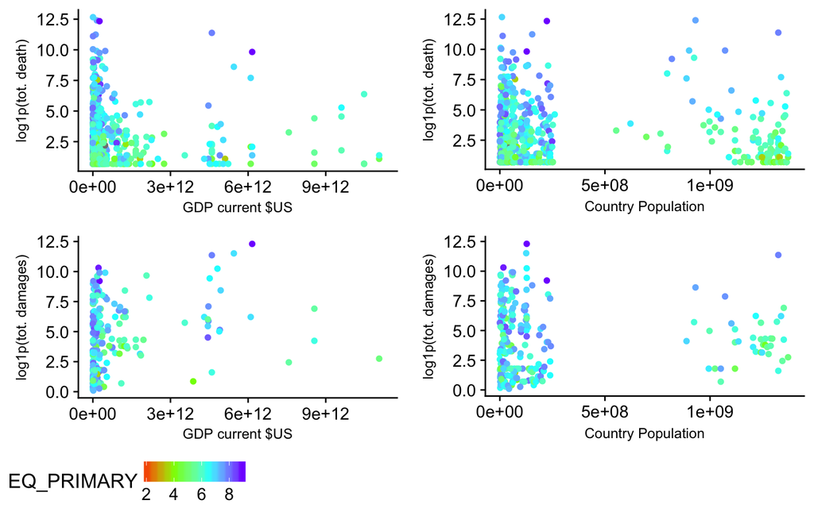

# Machine Learning Methods - Linear Regression Analysis

- High residual and low R-squared value in the summary of this model suggest a bad fit.

```
##
## Call:
## lm(formula = TOTAL_DEATHS ~ FOCAL_DEPTH + EQ_PRIMARY + INTENSITY +
##     LATITUDE + LONGITUDE, data = df_eq_gdp)
##
## Residuals:
##    Min     1Q Median     3Q    Max
## -12574  -5071  -2347    822 229070
##
## Coefficients:
##               Estimate Std. Error t value Pr(>|t|)
## (Intercept) -29396.051   9095.856  -3.232  0.00139 **
## FOCAL_DEPTH     -4.789     38.116  -0.126  0.90011
## EQ_PRIMARY    2579.113   1381.193   1.867  0.06302 .
## INTENSITY     1872.967    786.637   2.381  0.01801 *
## LATITUDE        50.497     52.875   0.955  0.34049
## LONGITUDE       10.689     13.159   0.812  0.41737
## ---
## Signif. codes:  0 '***' 0.001 '**' 0.01 '*' 0.05 '.' 0.1 ' ' 1
##
## Residual standard error: 17410 on 251 degrees of freedom
##   (1755 observations deleted due to missingness)
## Multiple R-squared:  0.06531,    Adjusted R-squared:  0.04669
## F-statistic: 3.508 on 5 and 251 DF,  p-value: 0.004401
```

# Machine Learning Methods - Linear Regression Analysis

- Including country’s GDP and population does not provide a good fit model.

```
##
## Call:
## lm(formula = TOTAL_DEATHS ~ FOCAL_DEPTH + EQ_PRIMARY + INTENSITY +
##     LATITUDE + LONGITUDE + GDP_currentUSD + Population, data = df_eq_gdp)
##
## Residuals:
##    Min     1Q Median     3Q    Max
## -22102  -5239  -1374   1977 219126
##
## Coefficients:
##                  Estimate Std. Error t value Pr(>|t|)
## (Intercept)    -3.603e+04  1.157e+04  -3.114  0.00214 **
## FOCAL_DEPTH     2.414e+01  6.273e+01   0.385  0.70083
## EQ_PRIMARY      3.053e+03  1.727e+03   1.768  0.07867 .
## INTENSITY       2.047e+03  1.006e+03   2.035  0.04330 *
## LATITUDE        3.940e+01  6.644e+01   0.593  0.55390
## LONGITUDE      -9.284e+00  1.778e+01  -0.522  0.60217
## GDP_currentUSD  2.611e-10  1.753e-09   0.149  0.88177
## Population      1.418e-05  4.637e-06   3.058  0.00256 **
## ---
## Signif. codes:  0 '***' 0.001 '**' 0.01 '*' 0.05 '.' 0.1 ' ' 1
##
## Residual standard error: 19070 on 186 degrees of freedom
##   (1818 observations deleted due to missingness)
## Multiple R-squared:  0.1173, Adjusted R-squared:  0.08412
## F-statistic: 3.532 on 7 and 186 DF,  p-value: 0.001382
```

# Machine Learning Methods - Random Forest

- Large mean of squared residuals and the negative value for the % of variance indicates that random forest method was not adequate to define a good fit model.

```
##                  %IncMSE IncNodePurity
## FOCAL_DEPTH    -0.215833    2477988429
## EQ_PRIMARY      6.183413    4834659130
## INTENSITY       4.422953   27634649725
## LATITUDE        3.690651    5535607345
## LONGITUDE       3.467354    5643303160
## GDP_currentUSD  4.940315    6390495863
## Population      6.871774   12252170534
```

```
##
## Call:
##  randomForest(formula = TOTAL_DEATHS ~ FOCAL_DEPTH + EQ_PRIMARY +      INTENSITY + LATITUDE + LONGITUDE + GDP_currentUSD + Population,      data = df_eq_gdp, importance = TRUE, ntree = 2000, na.action = na.omit)
##                Type of random forest: regression
##                      Number of trees: 2000
## No. of variables tried at each split: 2
##
##           Mean of squared residuals: 408750305
##                     % Var explained: -3.45
```

# Map the Earthquakes

- Total deaths and total damages was plotted every 10 years, and at certain regions (the Mediterranean and South America), the total loss has decreased over the years.

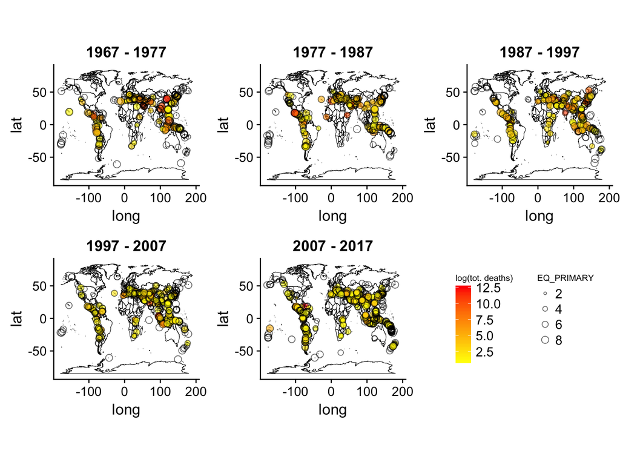

# Map the Earthquakes

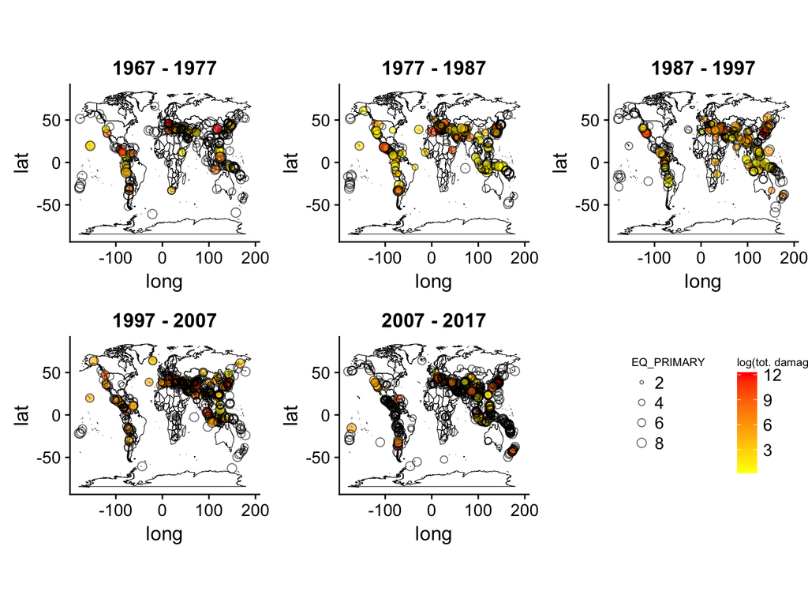

# Results

# Implications

- Results will be useful for the UN to budget emergency fund for earthquake-prone areas.
- E.g., Areas that suffer great loss during the past 50 years and also have high risk for earthquakes in the future, a greater amount of emergency fund should be budgeted.
- The analyses can be furthered to study similar correlations in individual country, state or even city.
- Using these results to identify countries, states and cities that have successfully reduced the total loss over the years and apply their strategies to other regions.